# RI-B5-04: Data aggregation: UK seafood supply chains

A.Lofstedt, B.Scheliga

14/07/2022

## Mapping seafood supply chains in the UK

This R Markdown document outlines how the data set to map UK seafood supply chains was created and edited.

The overall aim of this study is to reveal how the UK’s production and supply chains could be better aligned with consumption and dietary recommendations to bolster resilience, sustainability and safety, whilst optimising their nutritional impact, in working towards our ambition for net-zero emissions of all greenhouse gases by 2045. We are interested in gathering data from the past 10 years to assess how events like Brexit and the Covid epidemic have affected these supply chains.

Note: Scottish seafood trade data is proving difficult to obtain primarily because seafood destined/ leaving Scotland may be imported/ exported via ports throughout the UK e.g. Humberside, which are then transported across the border. Moreover, the amount of seafood (traded and produced) destined for human consumption is not specified. Such non-food uses include fishmeal, pet food and ornamental purposes. Therefore, UK seafood supply chains were mapped.

## Compilation of the dataset

Food balance sheets of fish and fisheries products were sourced from the Food and Agricultural Organisation (FAO). The dataset includes capture and aquaculture statistics for all finfish, crustaceans and molluscs from brackish, freshwater and marine environments. An advantage of using FAO food balance sheets is that the data is already categorised into production, imports, exports and non-food uses.

### Download FAO food balance sheets.

**Units in 1000 tonnes**

```r
# Loading file path to the data into a value
source("Data_filepath.R")# Data_filepath.R is listed in .gitignore-file. So, you will need to create that file yourself and provide your respected filepath using "data_dir <- [enter your here]"


# read FAO dataset (.csv)
FAO_food_balance<- read.csv(file=paste(data_dir,"FAOSTAT_data.csv", sep="/") , header = T)
str(FAO_food_balance)
```

```
## 'data.frame':    300 obs. of  14 variables:
##  $ ï..Domain.Code  : chr  "FBS" "FBS" "FBS" "FBS" ...
##  $ Domain          : chr  "Food Balances (2010-)" "Food Balances (2010-)" "Food Balances (2010-)" "Food Balances (2010-)" ...
##  $ Area.Code..FAO. : int  229 229 229 229 229 229 229 229 229 229 ...
##  $ Area            : chr  "United Kingdom of Great Britain and Northern Ireland" "United Kingdom of Great Britain and Northern Ireland" "United Kingdom of Great Britain and Northern Ireland" "United Kingdom of Great Britain and Northern Ireland" ...
##  $ Element.Code    : int  5511 5511 5511 5511 5511 5511 5511 5511 5511 5511 ...
##  $ Element         : chr  "Production" "Production" "Production" "Production" ...
##  $ Item.Code       : int  2761 2761 2761 2761 2761 2761 2761 2761 2761 2761 ...
##  $ Item            : chr  "Freshwater Fish" "Freshwater Fish" "Freshwater Fish" "Freshwater Fish" ...
##  $ Year.Code       : int  2010 2011 2012 2013 2014 2015 2016 2017 2018 2019 ...
##  $ Year            : int  2010 2011 2012 2013 2014 2015 2016 2017 2018 2019 ...
##  $ Unit            : chr  "1000 tonnes" "1000 tonnes" "1000 tonnes" "1000 tonnes" ...
##  $ Value           : num  172 174 180 179 193 ...
##  $ Flag            : chr  "Im" "Im" "Im" "Im" ...
##  $ Flag.Description: chr  "FAO data based on imputation methodology" "FAO data based on imputation methodology" "FAO data based on imputation methodology" "FAO data based on imputation methodology" ...
```

```r
## Use vroom for above

# Identify unique Item groups
unique(FAO_food_balance$Item)
```

```
## [1] "Freshwater Fish"    "Demersal Fish"      "Pelagic Fish"
## [4] "Marine Fish, Other" "Crustaceans"        "Cephalopods"
## [7] "Molluscs, Other"
```

Food balance sheets are measured in live weight equivalent in tonnes without accounting for processing losses, over-representing the amount available for processing losses.

```r
# Account for processing losses by applying conversion factors from HMRC
FAO_food_balance$CF<- ifelse(FAO_food_balance$Item %in% c("Freshwater Fish", "Demersal Fish", "Pelagic Fish", "Marine Fish, Other"), 0.49,
                     ifelse(FAO_food_balance$Item %in% c("Cephalopods", "Crustaceans", "Molluscs, Other"), 0.28,1))

unique(FAO_food_balance$CF)
```

```
## [1] 0.49 0.28
```

```r
FAO_food_balance$applied_CF<-FAO_food_balance$CF*FAO_food_balance$Value
```

Seafood availability was calculated as follows:
$$seafood availability = ((production - (feed +
other non food uses))- exports) + imports$$

```r
# Sum items per year and per element
FAO_food_balance_year<-aggregate(FAO_food_balance$applied_CF,by= list(FAO_food_balance$Year, FAO_food_balance$Element), FUN=sum)

# unstack dataframe

FAO_seafood_availability<-FAO_food_balance_year %>%
  pivot_wider(names_from = Group.2, values_from = x)

#seafood availability = ((production - (feed + other non food uses))- exports) + imports

FAO_seafood_availability$available<- ((FAO_seafood_availability$Production - (FAO_seafood_availability$`Other uses (non-food)`+FAO_seafood_availability$Feed)) - FAO_seafood_availability$`Export Quantity`)+FAO_seafood_availability$`Import Quantity`
```

### Data exploration

Seafood availability over the past 10 years

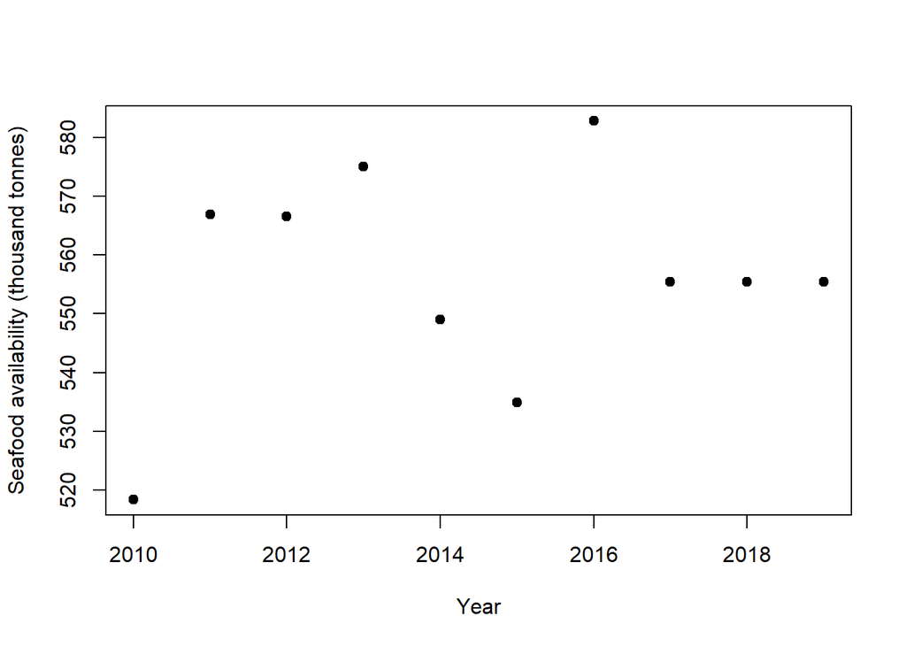

```r
# Plot seafood availability over the past 10  years.
plot(FAO_seafood_availability$available~ FAO_seafood_availability$Group.1,
     pch=19, xlab="Year", ylab="Seafood availability (thousand tonnes)")
```

Figure 1. Seafood availability in the UK between 2010 and 2019.

## UK fish consumption and purchasing data.

Three data sources were identified a) DEFRA family foods, b) National Diet and Nutrition Survey (NDNS) data and c) Kantar

### A) DEFRA family food data sets.

**Units in g/person/week**

DEFRA family food data sets include the average quantity of food and drink purchased per person per week for each food and drink category. It includes food purchased for UK households and food eaten out.

**Note**: saving a excel data file as a csv removes evidence of rounded values. All raw data were rounded to 2 decimal places and then saved as a csv file.

### A) Household purchases

```r
# read DEFRA household dataset (.csv)
DEFRA_household_data<- read.csv(file= paste(data_dir,"DEFRA.UK_households_edit.csv", sep="/"), header = T)

str(DEFRA_household_data)
```

```
## 'data.frame':    22 obs. of  53 variables:
##  $ Code           : int  100123 102 10201 10202 106 10601 10602 107 10701 10702 ...
##  $ Food.Category  : chr  "Fish" "Fish" "Fish" "Fish" ...
##  $ Food.Group     : chr  "Fish" "Fish" "Fish" "Fish" ...
##  $ Major.Food.Code: chr  "Sum" "White fish, fresh, chilled or frozen" "White fish, fresh, chilled or frozen" "White fish, fresh, chilled or frozen" ...
##  $ Minor.Food.Code: chr  "Sum" "Sum" "White fish, fresh or chilled" "White fish, frozen" ...
##  $ Units          : chr  "g" "g" "g" "g" ...
##  $ X1974          : num  123.37 43.75 35.44 8.31 2.7 ...
##  $ X1975          : num  127.79 47.94 37.25 10.69 2.49 ...
##  $ X1976          : num  130.56 48.46 34.45 14.01 2.33 ...
##  $ X1977          : num  118.05 44.52 33.03 11.49 2.37 ...
##  $ X1978          : num  121.7 46.4 33.2 13.2 2.2 ...
##  $ X1979          : num  128.77 45.24 32.31 12.93 2.41 ...
##  $ X1980          : num  136.94 47.87 31.86 16.01 2.75 ...
##  $ X1981          : num  140.61 49.87 33.38 16.49 2.37 ...
```

[output cut: 39 more lines]

```r
unique(DEFRA_household_data$Major.Food.Code)
```

```
##  [1] "Sum"
##  [2] "White fish, fresh, chilled or frozen"
##  [3] "Herrings and other blue fish, fresh, chilled or frozen"
##  [4] "Salmon, fresh, chilled or frozen"
##  [5] "Blue fish, dried or salted or smoked"
##  [6] "White fish, dried, salted or smoked"
##  [7] "Shellfish"
##  [8] "Takeaway fish"
##  [9] "Salmon, tinned"
## [10] "Other tinned or bottled fish"
## [11] "Ready meals and other fish products - frozen or not frozen"
## [12] "Takeaway fish meals and fish products"
```

```r
# Major food codes according to FAO groupings
DEFRA_household_data$FAO<- "Unknown"
DEFRA_household_data$FAO[DEFRA_household_data$Major.Food.Code == "White fish, fresh, chilled or frozen"]<- "Demersal"
DEFRA_household_data$FAO[DEFRA_household_data$Major.Food.Code == "White fish, dried, salted or smoked"]<- "Demersal"
DEFRA_household_data$FAO[DEFRA_household_data$Major.Food.Code == "Shellfish"]<- "Shellfish"
DEFRA_household_data$FAO[DEFRA_household_data$Major.Food.Code == "Herrings and other blue fish, fresh, chilled or frozen"] <-"Pelagic"
DEFRA_household_data$FAO[DEFRA_household_data$Major.Food.Code == "Salmon, fresh, chilled or frozen"]<- "Pelagic"
DEFRA_household_data$FAO[DEFRA_household_data$Major.Food.Code == "Blue fish, dried or salted or smoked"]<- "Pelagic"
DEFRA_household_data$FAO[DEFRA_household_data$Major.Food.Code == "Salmon, tinned"]<- "Pelagic"
```

### B) Eating out

Data were edited in excel prior to entering into R. EO food group “Fish and fisheries products” were selected and column information was duplicated to ensure all cells had data in.

**Note**: The amount of fish eaten out is underestimated because only products defined under “fish and fisheries” were selected. Some fisheries products were purchased as part of a different EO major code (cuisine) e.g. Indian: meat or fish based curry with sauce. However, the exact proportion of fish based curry is not defined.

```r
# read DEFRA eaten out dataset (.csv)
DEFRA_eaten_out_data<- read.csv(file= paste(data_dir,"DEFRA.UK_eaten_out_edit.csv", sep="/"), header = T)

str(DEFRA_eaten_out_data)
```

```
## 'data.frame':    14 obs. of  26 variables:
##  $ Code         : chr  "eo120" "eo1201" "eo120101" "eo120102" ...
##  $ X            : logi  NA NA NA NA NA NA ...
##  $ EO.Food.Group: chr  "Fish and fish products" "Fish and fish products" "Fish and fish products" "Fish and fish products" ...
##  $ EO.Major.code: chr  "Sum" "White fish" "White fish" "White fish" ...
##  $ EO.Minor.code: chr  "Total sum" "Sum" "White fish - grilled, steamed, baked or boiled - without sauce" "White fish - fried (incl in batter/breadcrumbs) - without sauce" ...
##  $ Units        : chr  "g" "g" "g" "g" ...
##  $ X2001.02     : num  14.701 9.32 1.524 7.796 0.859 ...
##  $ X2002.03     : num  14.033 8.688 1.268 7.42 0.901 ...
##  $ X2003.04     : num  13.855 8.315 1.2 7.115 0.774 ...
##  $ X2004.05     : num  13.86 8.491 1.293 7.198 0.811 ...
##  $ X2005.06     : num  14.349 8.609 1.053 7.556 0.859 ...
##  $ X2006        : num  14.366 8.854 1.127 7.727 0.723 ...
##  $ X2007        : num  13.19 7.869 1.1 6.769 0.738 ...
##  $ X2008        : num  13.117 8.142 0.893 7.25 0.837 ...
##  $ X2009        : num  13.652 8.044 0.961 7.083 0.693 ...
##  $ X2010        : num  13.533 8.327 0.953 7.374 0.641 ...
##  $ X2011        : num  13.419 8.296 1.09 7.206 0.656 ...
##  $ X2012        : num  13.741 7.948 0.968 6.98 0.74 ...
##  $ X2013        : num  13.134 7.59 0.803 6.786 0.404 ...
##  $ X2014        : num  14.101 8.486 0.949 7.537 0.673 ...
##  $ X2015        : num  14.838 8.76 1.008 7.753 0.793 ...
##  $ X201516      : num  14.574 8.696 0.966 7.73 0.831 ...
##  $ X201617      : num  14.79 8.344 0.945 7.399 0.854 ...
##  $ X201718      : num  14.287 7.853 0.877 6.977 0.743 ...
##  $ X201819      : num  15.64 8.69 1.13 7.56 1.11 ...
##  $ X201920      : num  14.962 8.306 1.02 7.285 0.706 ...
```

```r
unique(DEFRA_eaten_out_data$EO.Major.code)
```

```
## [1] "Sum"
## [2] "White fish"
## [3] "Fatty fish"
## [4] "Shellfish - without sauce or dressing (e.g. prawns, shrimps, oysters, crab)"
## [5] "Kippers and other smoked fish (e.g. smoked salmon)"
## [6] "Other fish products and unspecified 'fish' (e.g. squid, sushi, crabsticks)"
## [7] "Processed fish"
```

Fish commodities were aggregated according to FAO classification. “White fish” are assumed to be demersal species, “Fatty fish” and “Kippers” assumed to be pelagics, “Shellfish” equivalent to shellfish with all other commodities identified as “unknown”.

```r
# Major food codes according to FAO groupings.
DEFRA_eaten_out_data$FAO<- "Unknown"
DEFRA_eaten_out_data$FAO[DEFRA_eaten_out_data$EO.Major.code == "White fish"]<- "Demersal"
DEFRA_eaten_out_data$FAO[DEFRA_eaten_out_data$EO.Major.code == "Shellfish - without sauce or dressing (e.g. prawns, shrimps, oysters, crab)"]<- "Shellfish"
DEFRA_eaten_out_data$FAO[DEFRA_eaten_out_data$EO.Major.code == "Fatty fish"] <-"Pelagic"
DEFRA_eaten_out_data$FAO[DEFRA_eaten_out_data$EO.Major.code == "Kippers and other smoked fish (e.g. smoked salmon)"]<- "Pelagic"
```

### B) National Diet and Nutrition Survey (NDNS) data

**Units in g/ person**

Data were edited in excel prior to entering into R. Arithmetic mean was selected for all age groups.

```r
# Read in NDNS data
NDNS_data<-read.csv(file= paste(data_dir,"NDNS. Table 7.8_edit.csv", sep="/"), header = T)

str(NDNS_data)
```

```
## 'data.frame':    19 obs. of  7 variables:
##  $ Age.category        : chr  "Children 1.5-3 years" "Boys 4-10 years" "Girls 4-10 years" "Children 4-10 years" ...
##  $ Total.fish.g.day    : chr  "Arithmetic Mean" "Arithmetic Mean" "Arithmetic Mean" "Arithmetic Mean" ...
##  $ X.2008.09...2009.10.: num  8.52 12.77 10.24 11.43 10.12 ...
##  $ X.2010.11...2011.12.: num  8.52 11.44 8.92 10.32 12.61 ...
##  $ X.2012.13...2013.14.: num  9.62 11.12 10.38 10.76 15.11 ...
##  $ X.2014.15.2015.16.  : num  8.76 12.79 11.79 12.3 14.43 ...
##  $ X.2016.17.2018.19.  : num  7.7 11.3 11.2 11.3 12.7 ...
```

```r
## Aggregate all age cohorts together
```

### C) Kantar

```r
# read Kantar dataset (.csv)
```